# Analysis by Stephanie (RMarkdown)

# Support Vector Machine

#### BEST ACCURACIES FROM ALL TESTING DONE FROM ANALYSIS BY STEPHANIE.R FILE

```r
library(e1071)
# Change target variable to factor

z_completetrain$target <- as.factor(z_completetrain$target)

z_normaltrain$target <- as.factor(z_normaltrain$target)

firsttrain$target <- as.factor(firsttrain$target)

secondtrain$target <- as.factor(secondtrain$target)

thirdtrain$target <- as.factor(thirdtrain$target)
```

## All Sensors and Measurments

### from z normal complete data set using polynomial kernel

```r
# Choosing tuning parameters based on cross-validation
tobj1 <- tune(svm, target~., data= z_completetrain, kernel = "polynomial", ranges = list(cost = c(0.001, 0.01, 0.1, 1, 10, 100), degree = c(3:6))) # takes a while to load
summary(tobj1) # choose 100 as the cost parameter and 3  as the degree because it has the smallest error
```

```
##
## Parameter tuning of 'svm':
##
## - sampling method: 10-fold cross validation
##
## - best parameters:
##  cost degree
##   100      3
##
## - best performance: 0.10725
##
## - Detailed performance results:
##     cost degree   error dispersion
## 1  1e-03      3 0.75425 0.02220642
## 2  1e-02      3 0.58450 0.03086260
## 3  1e-01      3 0.41350 0.02614596
## 4  1e+00      3 0.21525 0.02212496
## 5  1e+01      3 0.13375 0.01948112
## 6  1e+02      3 0.10725 0.01547624
## 7  1e-03      4 0.74275 0.02025703
## 8  1e-02      4 0.60700 0.03653005
## 9  1e-01      4 0.48275 0.02870951
## 10 1e+00      4 0.30075 0.02153969
## 11 1e+01      4 0.16550 0.02660931
## 12 1e+02      4 0.12175 0.01349125
## 13 1e-03      5 0.72650 0.03395667
## 14 1e-02      5 0.61500 0.03157883
## 15 1e-01      5 0.50075 0.03071034
## 16 1e+00      5 0.36475 0.02225016
## 17 1e+01      5 0.21675 0.02014013
## 18 1e+02      5 0.13900 0.01845415
## 19 1e-03      6 0.72425 0.02920355
## 20 1e-02      6 0.61800 0.03045488
## 21 1e-01      6 0.51425 0.02796451
## 22 1e+00      6 0.41450 0.03386657
## 23 1e+01      6 0.27175 0.01814486
## 24 1e+02      6 0.17900 0.02183270
```

```r
svm1 <- svm(target~., data=z_completetrain, method="C-classification", scale = FALSE, kernal="polynomial", cost=100, degree=3) # polynomial kernel
summary(svm1) # summary of svm
```

```
##
## Call:
## svm(formula = target ~ ., data = z_completetrain, method = "C-classification",
##     kernal = "polynomial", cost = 100, degree = 3, scale = FALSE)
##
##
## Parameters:
##    SVM-Type:  C-classification
##  SVM-Kernel:  radial
##        cost:  100
##
## Number of Support Vectors:  1355
##
##  ( 296 242 292 217 308 )
##
##
## Number of Classes:  5
##
## Levels:
##  Bus Car Still Train Walking
```

```r
#svm1$SV # observation index and coefficients of the predictors for the support vectors
pred1 <- predict(svm1, z_completetest)
truth1 <- z_completetest$target
table(truth1, pred1) # Not that many mis-classified for each variable (only a few for each)
```

```
##          pred1
## truth1    Bus Car Still Train Walking
##   Bus     345   4     2    20      10
##   Car      22 346     3     5       5
##   Still     5   2   369    14       7
##   Train    11   6    14   338       4
##   Walking   9   3     4     0     345
```

```r
# Accuracy for testing
correct <- 0
for (i in 1:5) {
  correct <- correct + table(truth1, pred1)[i,i]
}
correct/nrow(z_completetest) # 92.08% accuracy
```

```
## [1] 0.9207607
```

```r
# Accuracy for training
pred1 <- predict(svm1, z_completetrain)
truth1 <- z_completetrain$target
correct <- 0
for (i in 1:5) {
  correct <- correct + table(truth1, pred1)[i,i]
}
correct/nrow(z_completetrain) # 97.6% accuracy
```

```
## [1] 0.976
```

```r
# compute decision values and probabilities:
x <- subset(z_completetrain, select = -target)
pred <- predict(svm1, x, decision.values = TRUE)
attr(pred, "decision.values")[1:37,]
```

```
##      Bus/Walking  Bus/Still      Bus/Car  Bus/Train Walking/Still Walking/Car
## 4999   1.4801177  2.6629720   2.06236059  2.2077719     2.4061904 -0.84430461
## 2214  -1.1642931 -1.8022088  -1.16327911 -0.3144678     1.0635836  1.37070142
## 5550   1.9379821 -0.9999227   4.24620753  1.4141848    -1.9084793  0.11974126
## 442    1.4428889  2.2397498   2.33993502  0.7263131    -0.6687032 -0.52131640
## 743    2.9092999  5.0515597   2.04325324  1.7669698     0.6422661  0.80399329
## 5004   0.1209973 -1.0001490   4.13463765  1.2399194    -2.3065233  2.89731590
## 1012  -1.4616442 -1.9257735  -1.00201744 -1.1179329     1.3271645  1.19410713
## 1094  -1.9178839 -0.5610604  -0.46715011 -0.2062407     1.5630313  1.52087253
## 4288   2.5823596 -2.0357027  -9.84513573 -4.4206769     3.3678398 -2.64691340
## 1787   2.5063444 -1.3783488   0.25296532 -1.6754364    -3.5609416 -0.74381637
## 5734   3.9602622  5.3438570  -0.42434563  3.6745642     9.8698526 -3.43622901
## 4421   2.8167993  2.4726588   2.98298435 -0.7175973    -1.0325465 -0.69008551
## 4591  -1.7207137 -4.1149703  -5.45095477 -4.0353286     3.8856303  1.51602880
## 103   -2.6005394 -0.2900282  -2.31867283  0.2685955     0.9998987  1.35807483
```

[output cut: 61 more lines]

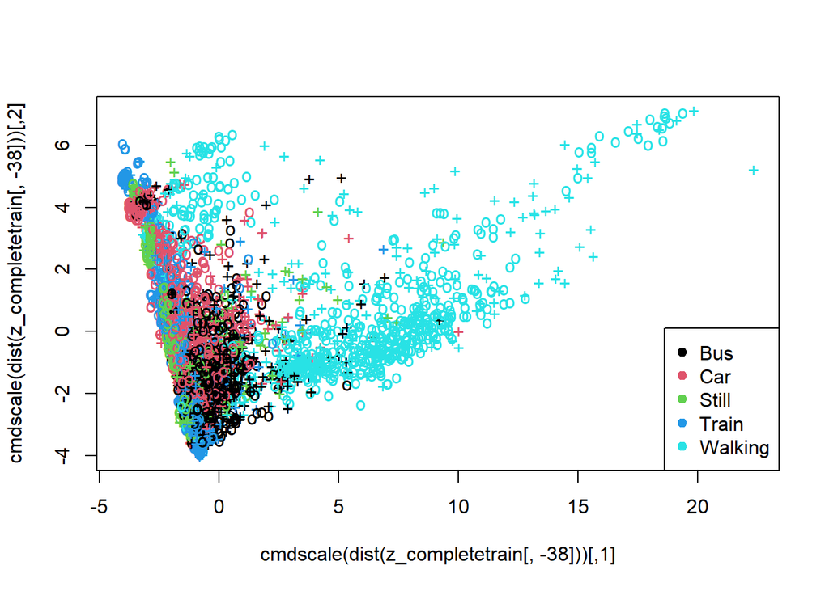

```r
# visualize (classes by color, SV by crosses):
plot(cmdscale(dist(z_completetrain[,-38])),col = as.integer(z_completetrain[,38]), pch = c("o","+")[1:4000 %in% svm1$index + 1])
legend("bottomright", legend=c("Bus", "Car", "Still", "Train", "Walking"), col=1:5, pch=19)
```

This is the best accuracy out of all svm testing for both test and train data sets.

## All Sensors’ Means and Time

### From z normal data set using polynomial kernel (just the means and time, data is normalized)

```r
# Choosing tuning parameters based on cross-validation
tobj2 <- tune(svm, target~., data= z_normaltrain, kernel = "polynomial", ranges = list(cost = c(0.001, 0.01, 0.1, 1, 10, 100), degree = c(3:6))) # takes a while to load
summary(tobj2) # choose 100 as the cost parameter and 3  as the degree because it has the smallest error
```

```
##
## Parameter tuning of 'svm':
##
## - sampling method: 10-fold cross validation
##
## - best parameters:
##  cost degree
##   100      4
##
## - best performance: 0.13
##
## - Detailed performance results:
##     cost degree   error dispersion
## 1  1e-03      3 0.73200 0.02673948
## 2  1e-02      3 0.56675 0.03046058
## 3  1e-01      3 0.42275 0.02987125
## 4  1e+00      3 0.22250 0.02516611
## 5  1e+01      3 0.15650 0.02045320
## 6  1e+02      3 0.13525 0.02011944
## 7  1e-03      4 0.71000 0.03064129
## 8  1e-02      4 0.58000 0.02730995
## 9  1e-01      4 0.46925 0.02796451
## 10 1e+00      4 0.29550 0.02808222
## 11 1e+01      4 0.17725 0.02011944
## 12 1e+02      4 0.13000 0.02071634
## 13 1e-03      5 0.68725 0.04658400
## 14 1e-02      5 0.58125 0.02761969
## 15 1e-01      5 0.48725 0.03548180
## 16 1e+00      5 0.35425 0.02254779
## 17 1e+01      5 0.21250 0.02169869
## 18 1e+02      5 0.14750 0.01889297
## 19 1e-03      6 0.67325 0.03102530
## 20 1e-02      6 0.57950 0.02907844
## 21 1e-01      6 0.49650 0.03672722
## 22 1e+00      6 0.40500 0.02330355
## 23 1e+01      6 0.27300 0.02551688
## 24 1e+02      6 0.18025 0.01865066
```

```r
svm2 <- svm(target~., data=z_normaltrain, method="C-classification", scale = FALSE, kernal="polynomial", cost=100, degree=3) # polunomial kernel
summary(svm2) # summary of svm
```

```
##
## Call:
## svm(formula = target ~ ., data = z_normaltrain, method = "C-classification",
##     kernal = "polynomial", cost = 100, degree = 3, scale = FALSE)
##
##
## Parameters:
##    SVM-Type:  C-classification
##  SVM-Kernel:  radial
##        cost:  100
##
## Number of Support Vectors:  1343
##
##  ( 317 207 271 246 302 )
##
##
## Number of Classes:  5
##
## Levels:
##  Bus Car Still Train Walking
```

```r
#svm2$SV # observation index and coefficients of the predictors for the support vectors
pred2 <- predict(svm2, z_normaltest)
truth2 <- z_normaltest$target
table(truth2, pred2) # More mis-classified variables, but not so much for walking
```

```
##          pred2
## truth2    Bus Car Still Train Walking
##   Bus     340  15     3    16       7
##   Car      36 327     9     9       0
##   Still     1   4   379    10       3
##   Train    13   8    19   330       3
##   Walking  13   1     7     1     339
```

```r
# Accuracy for testing
correct <- 0
for (i in 1:5) {
  correct <- correct + table(truth2, pred2)[i,i]
}
correct/nrow(z_normaltest) # 90.59% accuracy
```

```
## [1] 0.9059694
```

```r
# Accuracy for training
pred2 <- predict(svm2, z_normaltrain)
truth2 <- z_normaltrain$target
correct <- 0
for (i in 1:5) {
  correct <- correct + table(truth2, pred2)[i,i]
}
correct/nrow(z_normaltrain) # 95% accuracy
```

```
## [1] 0.95
```

This is the second best accuracy out of all svm testing for both test and train data sets. It uses less feature variables, only 10 out of the 37 from above and the accuracy is still high.

## Important Sensors (Means Only)

```r
# Choosing tuning parameters based on cross-validation
tobj3 <- tune(svm, (as.formula(paste(colnames(z_completetrain)[38], "~", paste(colnames(z_completetrain)[c(2, 6, 10, 22, 26, 30, 34)], collapse = "+"), sep = ""))), data= z_completetrain, kernel = "polynomial", ranges = list(cost = c(0.001, 0.01, 0.1, 1, 10, 100), degree = c(3:6))) # takes a while to load
summary(tobj3) # choose 100 as the cost parameter and 3  as the degree because it has the smallest error
```

```
##
## Parameter tuning of 'svm':
##
## - sampling method: 10-fold cross validation
##
## - best parameters:
##  cost degree
##   100      4
##
## - best performance: 0.16625
##
## - Detailed performance results:
##     cost degree   error  dispersion
## 1  1e-03      3 0.72300 0.023267765
## 2  1e-02      3 0.56325 0.018068158
## 3  1e-01      3 0.42825 0.033104422
## 4  1e+00      3 0.25625 0.017490077
## 5  1e+01      3 0.20900 0.014443376
## 6  1e+02      3 0.17025 0.014740816
## 7  1e-03      4 0.68225 0.039729118
## 8  1e-02      4 0.57600 0.019727308
## 9  1e-01      4 0.50450 0.023944380
## 10 1e+00      4 0.29900 0.017880778
## 11 1e+01      4 0.21875 0.016884000
## 12 1e+02      4 0.16625 0.012090515
## 13 1e-03      5 0.69950 0.018020051
## 14 1e-02      5 0.57525 0.021195191
## 15 1e-01      5 0.51450 0.022724192
## 16 1e+00      5 0.34925 0.020851659
## 17 1e+01      5 0.22625 0.019729068
## 18 1e+02      5 0.17650 0.015420045
## 19 1e-03      6 0.69275 0.017418461
## 20 1e-02      6 0.57650 0.019407902
## 21 1e-01      6 0.52125 0.021866070
## 22 1e+00      6 0.38200 0.027381056
## 23 1e+01      6 0.28425 0.024945775
## 24 1e+02      6 0.20300 0.009986101
```

```r
svm3 <- svm(as.formula(paste(colnames(z_completetrain)[38], "~", paste(colnames(z_completetrain)[c(2, 6, 10, 22, 26, 30, 34)], collapse = "+"), sep = "")), data=z_completetrain, method="C-classification", scale = FALSE, kernal="polynomial", cost=100, degree=3) # polynomial kernel
summary(svm3) # summary of svm
```

```
##
## Call:
## svm(formula = as.formula(paste(colnames(z_completetrain)[38], "~",
##     paste(colnames(z_completetrain)[c(2, 6, 10, 22, 26, 30, 34)],
##         collapse = "+"), sep = "")), data = z_completetrain, method = "C-classification",
##     kernal = "polynomial", cost = 100, degree = 3, scale = FALSE)
##
##
## Parameters:
##    SVM-Type:  C-classification
##  SVM-Kernel:  radial
##        cost:  100
##
## Number of Support Vectors:  1571
##
##  ( 375 216 298 323 359 )
##
##
## Number of Classes:  5
##
## Levels:
##  Bus Car Still Train Walking
```

```r
#svm3$SV # observation index and coefficients of the predictors for the support vectors
pred3 <- predict(svm3, z_completetest)
truth3 <- z_completetest$target
table(truth3, pred3) # Not that many mis-classified for each variable (only a few for each and not many for walking)
```

```
##          pred3
## truth3    Bus Car Still Train Walking
##   Bus     314  33     4    20      10
##   Car      33 317    19    12       0
##   Still     6   3   370    15       3
##   Train    18   7    31   313       4
##   Walking   9   5     6     2     339
```

```r
# Accuracy for testing
correct <- 0
for (i in 1:5) {
  correct <- correct + table(truth3, pred3)[i,i]
}
correct/nrow(z_completetest) # 87.32% accuracy
```

```
## [1] 0.8732171
```

```r
# Accuracy for training
pred3 <- predict(svm3, z_completetrain)
truth3 <- z_completetrain$target
correct <- 0
for (i in 1:5) {
  correct <- correct + table(truth3, pred3)[i,i]
}
correct/nrow(z_completetrain) # 90.3% accuracy
```

```
## [1] 0.903
```

The sensors time, gyroscope uncalibrated and game rotation vector have been removed because these sensors are not too helpful or are unnecessary in predicting the response variable. Time varies too much among the variables, so it is not very good in predicting. Gyroscope uncalibrated is a biased sensor causing biasness in the svm prediction model and game rotation vector is unnecessary because it is a combination or acceleometer and gyroscope which are already being used. This is the third best accuracy out of all svm testing for both test and train data sets. It uses less feature variables, only 7 out of the 37 from above and the accuracy is pretty still high.